# XChromosomeFertility

Eugene Gardner

30 July 2020

# 1. Startup and Introduction

This document contains UKBB data and uses it to assess hemizgyous variant carriers against a variety of phenotypes. If using data produced by this repo, please cite [our manuscript](https://www.medrxiv.org/content/10.1101/2020.03.18.20037960v1).

**Big Note**: The first part of this document involves running scripts to generate text files required for downstream analysis. *PLEASE* start there and make sure all scripts ran successfully. All scripts for this section are available in the folder `./scripts/` and *will not* run as part of this document.

**Big Note**: You also need to have access to UKBiobank, but this script is agnostic to the UKBiobank application number. You should be able to download a bulk phenotype file and, if it contains the correct phenotypes as referred to in the manuscript and in the file `rawdata/phenofiles/fields_to_extract.txt`, you should be able to reproduce our data and figures.

You can view a compiled html version of this document with all code run either within this repository at `compiled_htmls/PhenotypeTesting.html` or on [github](https://htmlpreview.github.io/?https://github.com/hilarymartin/DDD_chrX/UKBB_Analysis/blob/master/compiled_html/PhenotypeTesting.html).

## 1A. Libraries

```r
knitr::opts_chunk$set(
    echo = TRUE,
    message = FALSE,
    warning = FALSE ## Warnings turned off to squelch unecessary ggplot noise in kintted document. Have checked all for accuracy.
)

## Quietly Load Libraries
load.package <- function(name) {
  suppressMessages(suppressWarnings(library(name, quietly = T, warn.conflicts = F, character.only = T)))
}

load.package("biomaRt") ## Get gene lists we need
load.package("readxl") ## Read Supplemental Excel tables
load.package("data.table") ## Better than data.frame
load.package("patchwork") ## Arranging ggplots
load.package("broom") ## Makes getting covars out of lm much tidier
load.package("meta") ## For doing meta analysis
load.package("mratios") ## Need this to calculate 95% CIs for ratios of two means
load.package("svglite") ## Need to create figures properly (ggsave doesn't like anything with an alpha)
load.package("tidyverse") ## Takes care of ggplot, tidyr, dplyr, and stringr
```

## 1B. Themes

Set themes for internal figures just for testing purposes:

```r
theme <- theme(panel.background=element_rect(fill="white"),line=element_line(size=1,colour="black",lineend="round"),axis.line=element_line(size=1),text=element_text(size=16,face="bold",colour="black"),axis.text=element_text(colour="black"),axis.ticks=element_line(size=1,colour="black"),axis.ticks.length=unit(.1,"cm"),strip.background=element_rect(fill="white"),axis.text.x=element_text(angle=45,hjust=1),legend.position="blank",panel.grid.major=element_line(colour="grey",size=0.5))

## Default theme w/legend
theme.legend <- theme + theme(legend.position="right")

## M/F Colour Scheme:
male <- "#38BCA0"
female <- "#7B06F8"

sex.colours <- c(male, female)
names(sex.colours) <- c("Male","Female")
sex.colours.fill <- scale_fill_manual(name = "Sex",values=sex.colours,guide=guide_legend(reverse=F))
sex.colours.colour <- scale_colour_manual(name = "Sex",values=sex.colours, guide=guide_legend(reverse=F))
sex.colours.fill.rev <- scale_fill_manual(name = "Sex",values=sex.colours,guide=guide_legend(reverse=T))
sex.colours.colour.rev <- scale_colour_manual(name = "Sex",values=sex.colours, guide=guide_legend(reverse=T))

## Variant Colour Scheme:
alt.colours <- c("#9AD7E5",
                 "#D17A86",
                 "#969FAD")
```

Theme for main text/supplemental figures (making font size smaller):

```r
theme.figures <- theme(panel.background=element_rect(fill="white"),line=element_line(size=1,colour="black",lineend="round"),axis.line=element_line(size=1),text=element_text(size=10,face="bold",colour="black"),axis.text=element_text(colour="black"),axis.ticks=element_line(size=1,colour="black"),axis.ticks.length=unit(.1,"cm"),strip.background=element_rect(fill="white"),axis.text.x=element_text(angle=45,hjust=1),legend.position="blank",panel.grid.major=element_line(colour="grey",size=0.5))

## Default theme w/legend
theme.figures.legend <- theme.figures + theme(legend.position="right")
```

## 1C. Prepping Storage Directories

This just unpacks the tarball of provided data resources at `rawdata.tar.gz`

```bash
tar -zxf rawdata.tar.gz
```

# 2. Generating Required Text Files

Example code for downloading and initial processing UKBB phenotype file. None of the code in this section will actually be run.

## 2A. Creating Master Phenotype File:

This code chunk is not evaluated here but is provided for replication purposes. This code chunk assumes that the user has already gained access to, and [downloaded](http://biobank.ndph.ox.ac.uk/showcase/), relevant phenotype fields and has aquired the encoded phenotype file (like ukb00000.enc). The tools used below are also available via the [UKBiobank datashowcase website](http://biobank.ndph.ox.ac.uk/showcase/download.cgi). More information on downloading can be found [here](https://biobank.ctsu.ox.ac.uk/~bbdatan/Accessing_UKB_data_v2.1.pdf).

```bash
## First step involves downloading and decoding individual phenotype data. Keyvalue is the key provided via email when you apply for bulk download. This will create a decoded file ukb00000.enc_ukb
ukbunpack ukb00000.enc <keyvalue>

## Next, convert the file to a tab-delimited format:
ukbconv ukb00000.enc_ukb txt

## Create a data dictionary (so we know where phenotypes are in the file!)
ukbconv ukb00000.enc_ukb docs

## This should result in 2 required files for further processing:
# ukb00000.txt
# ukb00000.html
```

**Note** the following processing data expects the "ukb00000.*" data to be in the unpacked `rawdata/phenofiles/` directory!

This code chunk extracts phenotypes of relevance from the master phenotype file that is downloaded and processed above. It is run with the script: `./scripts/extract_phenotypes.pl`.

This script is slower than it should be due to an issue with text format encoding of the UKBB-created TSV file on MacOS. If running this code on a UNIX system, would suggest switching the ‘exec’ call at the bottom of this script to use cut for additional speed. It should mean the script executes in ~30s rather than 5mins.

```bash
./scripts/extract_phenotypes.pl
```

## 2B. Setting Unrelated Individuals:

1. Download the relatedness file using the (ukbgene)[http://biobank.ndph.ox.ac.uk/showcase/refer.cgi?id=664] tool
2. Place the file in `./rawdata/phenofiles/`
3. Running the provided script to generate a list of individuals to filter - at: `./scripts/get_relateds.R`.

```bash
## 1. Run ukbgene rel. This will download a file like: ukbXXXXX_rel_sYYYYYY.dat, where X represents your application ID, and 488288 represents the file version
ukbgene rel

## 2. Get related individuals to filter (change the name of the .dat to your specific file):
./scripts/get_relateds.R ukbXXXXX_rel_sYYYYYY.dat > raw_data/phenofiles/relateds.out
## Format the output file to be readable by R
perl -ne 'if ($_ =~ /\"(\d{7})\"/) {print "$1\n";}' raw_data/phenofiles/relateds.out > raw_data/phenofiles/relateds.txt
```

# 3. Phenotype Data

Read in the master phenotype and related individuals file that was created in the previous section

```r
UKBB.raw.phenotypes <- fread("rawdata/phenofiles/ukbb_phenotypes.txt")
UKBB.raw.phenotypes[,eid:=as.character(eid)]
```

```r
related.individuals <- fread("rawdata/phenofiles/relateds.txt", header = F)
setnames(related.individuals,"V1","eid")
related.individuals[,eid:=as.character(eid)]
```

## 3A. Generic Phenotypes

Grabbing generic phenotypes age, sex, ancestry, European ancestry status and adding them to the main UKBB.phenotype.data table.

This also filters out individuals that are not broadly European.

```r
## Data table of all UKBB population data:
PCAs<-c(1:30)
for (i in PCAs) {
  PCAs[i] <- paste("22009-0",i,sep=".")
}
fields <- c("eid","22006-0.0","31-0.0","21022-0.0",PCAs)
UKBB.phenotype.data <- UKBB.raw.phenotypes[,..fields]

setnames(UKBB.phenotype.data,c(fields),c("eid","white.british.ancestry","sexPulse","agePulse","PC1","PC2","PC3","PC4","PC5","PC6","PC7","PC8","PC9","PC10","PC11","PC12","PC13","PC14","PC15","PC16","PC17","PC18","PC19","PC20","PC21","PC22","PC23","PC24","PC25","PC26","PC27","PC28","PC29","PC30"))

## Remove all non-white British (determined direct by UKBB and taken from the pheno file)
UKBB.phenotype.data <- UKBB.phenotype.data[!is.na(white.british.ancestry)]
paste0("Number of Broadly Euro Indiv: ", table(UKBB.raw.phenotypes[,`22006-0.0`]))
```

```
## [1] "Number of Broadly Euro Indiv: 409617"
```

```r
## Remove all related individuals:
UKBB.phenotype.data <- UKBB.phenotype.data[!eid %in% related.individuals[,eid]]

## Change sex to be 1 = male, 2 = female instead of 0,1.
## This is a distinction made for an old project to keep it consistent.
UKBB.phenotype.data[,sexPulse:=ifelse(sexPulse == 0, 2, 1)]

## Add agePulse.squared covar:
UKBB.phenotype.data[,agePulse.squared:=agePulse^2]
paste0("Number of Individuals after filtering: ",nrow(UKBB.phenotype.data))
```

```
## [1] "Number of Individuals after filtering: 342717"
```

```r
rm(PCAs,fields,i)
```

## 3B. Fertility

Interesting number of children. Just plotting Male vs Female for QC purposes (even though we’re only intested in females in this document).

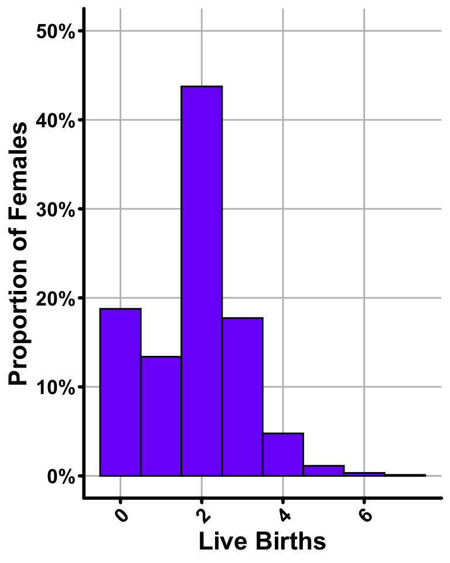

```r
fertility.metrics <- UKBB.raw.phenotypes[,c("eid",
                                            "2405-0.0", ## Children Fathered
                                            "2734-0.0" ## Live Births
                                            )]

## Replace all NAs with a double value to make filtering easier
fertility.metrics[is.na(fertility.metrics)] <- -9

setnames(fertility.metrics,names(fertility.metrics),c("eid",
                                                      "children.fathered",
                                                      "live.births"))

# Number of live births:
fertility.metrics[,live.births:=if_else(live.births > 7, -9, live.births)]
fertility.metrics[,live.births:=if_else(live.births < 0, -9, live.births)]

ggplot(fertility.metrics[live.births>=0],aes(live.births,..density..)) +
  geom_histogram(binwidth = 1,colour="black",fill=female) +
  xlab("Live Births") +
  scale_y_continuous(name = "Proportion of Females", limits=c(0,0.5), labels = paste0(c(0,10,20,30,40,50),"%")) +
  theme
```

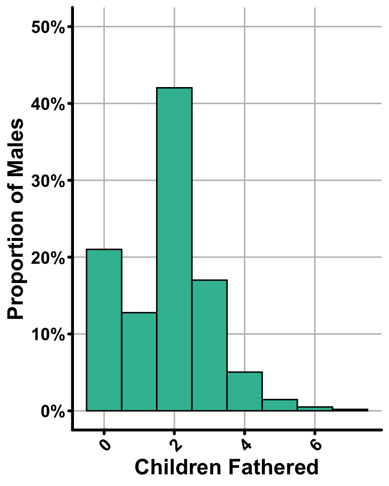

```r
# Children fathered
fertility.metrics[,children.fathered:=if_else(children.fathered > 7, -9, children.fathered)]
fertility.metrics[,children.fathered:=if_else(children.fathered < 0, -9, children.fathered)]

ggplot(fertility.metrics[children.fathered>=0],aes(children.fathered,..density..)) +
  geom_histogram(binwidth = 1,colour="black",fill=male) +
  xlab("Children Fathered") +
  scale_y_continuous(name = "Proportion of Males", limits=c(0,0.5), labels = paste0(c(0,10,20,30,40,50),"%")) +
  theme
```

```r
## Now convert all the -9s back to NA
fertility.metrics <- fertility.metrics[,c("eid","children.fathered","live.births")]
fertility.metrics[,children.fathered:=if_else(children.fathered==-9,as.numeric(NA),children.fathered)]
fertility.metrics[,live.births:=if_else(live.births==-9,as.numeric(NA),live.births)]

UKBB.phenotype.data <- merge(UKBB.phenotype.data,fertility.metrics,by="eid")
rm(fertility.metrics)
```

## 3C. Fluid Intelligence

This section looks at UKBB “Fluid Intelligence”.

The field of relevance for us is 20016-0.0. There is no array data (only 1 test was done, but 3 instances - we’re using instance 0).

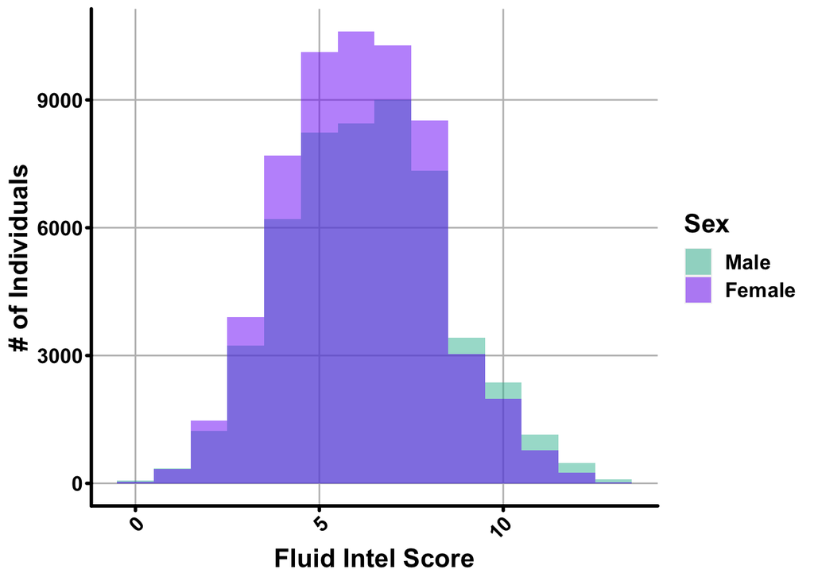

```r
## Grab fluid intel from the raw phenotypes:
fluid.intel.table <- UKBB.raw.phenotypes[,c("eid","20016-0.0")]
fluid.intel.table[,fluid.intel:=if_else(is.na(`20016-0.0`),as.integer(NA),`20016-0.0`)]
ggplot(merge(UKBB.phenotype.data,fluid.intel.table,by="eid"),aes(fluid.intel,group=as.factor(sexPulse),fill=as.factor(sexPulse))) +
  geom_histogram(binwidth = 1, position="identity", alpha = 0.5) +
  scale_alpha_continuous(range=c(0,1)) +
  scale_fill_manual(values=c(male,female),guide=guide_legend(title="Sex"),labels=c("Male","Female")) +
  scale_x_continuous(name="Fluid Intel Score") +
  scale_y_continuous(name = "# of Individuals") +
  theme.legend
```

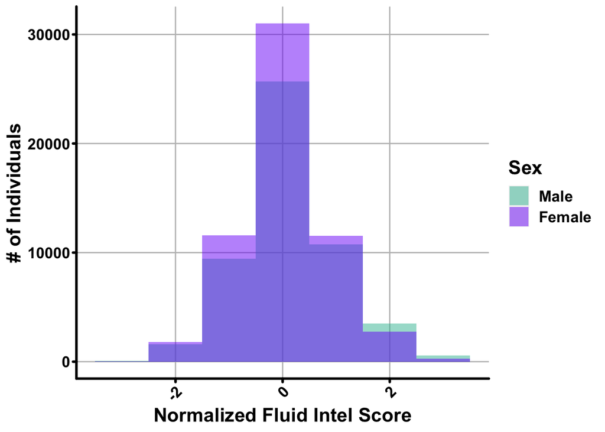

```r
## Normalize fluid intelligence
fluid.intel.table[,fluid.intel:=(fluid.intel-mean(fluid.intel,na.rm=T))/sd(fluid.intel,na.rm=T)]
ggplot(merge(UKBB.phenotype.data,fluid.intel.table,by="eid"),aes(fluid.intel,group=as.factor(sexPulse),fill=as.factor(sexPulse))) +
  geom_histogram(binwidth = 1, position="identity", alpha = 0.5) +
  scale_alpha_continuous(range=c(0,1)) +
  scale_fill_manual(values=c(male,female),guide=guide_legend(title="Sex"),labels=c("Male","Female")) +
  scale_x_continuous(name="Normalized Fluid Intel Score") +
  scale_y_continuous(name = "# of Individuals") +
  theme.legend
```

```r
## Merge with remaining phenotypes
UKBB.phenotype.data <- merge(UKBB.phenotype.data,fluid.intel.table[,c("eid","fluid.intel")],by="eid",all.x=T)

rm(fluid.intel.table)
```

# 4. Assembling Sequencing/Array Data

## 4A. Load Gene Lists For Phenotype Testing

We have provided in this document our gene lists that we have used for our association testing

### Generic Lists

This code block just loads our generic lists that we created above, namely:

1. Our hg19 -> hg38 conversion table

```r
## Load gene translation file
gene.translate <- fread("rawdata/genelists/hg38_to_hg19_ENSG.txt", header=F)
setnames(gene.translate,names(gene.translate),c("hg38.GENE","hg19.GENE"))

## Generate gene lists for phenotype testing:

## hemizygous gene lists:
gene.lists=c("hemizygous_DD_genes.ENSG.txt",
             "hemizygous_DD_genes_affecting_brain_with_LoF_mechanism.ENSG.txt",
             "hemizygous_DD_genes_affecting_brain.ENSG.txt",
             "hemizygous_DD_genes_consensus.ENSG.txt"
             )

names(gene.lists)=gsub(".txt","",basename(gene.lists))
names(gene.lists)=gsub(".ENSG","",names(gene.lists))
gene.lists <- as.list(gene.lists)

## Now make a vector of each gene list while getting rid of genes missing from Hg38:
for (g in names(gene.lists)) {

  file <- paste0("rawdata/genelists/",get(g,gene.lists))
  current.genes <- fread(file,header=F)
  current.genes <- current.genes[,V1]
  current.genes <- current.genes[current.genes %in% gene.translate[,hg19.GENE]]
  gene.lists[g] = list(current.genes)

}
```

## 4B. Variant Data

### SNV Data

#### Downloading Requisite Data From UKBB

Section tbd, but need to make sure to get two files:

1. Variant calls themselves: `rawdata/snvresources/counts.ukbb_wes.txt`
2. Field of ‘has wes’ from our derived data. I have already created a fake version at `rawdata/snvresources/has_exome.txt`

This data is not going to be available until final publication of the manuscript. This is due to guidelines from UK Biobank that do not allow returned data fields for studies not yet through peer review. We cannot make these calls available as part of this repository due to patient/subject protection.

#### Annotating Rare Variants in UKBB

SNV and InDel annotation is handled by the document `SNVCalling_Filtering.Rmd` within this repository. Please see that document for details on how to perform SNV QC and annotation.

#### Build Data Files

This section does the actual loading of UKBB SNV data into R.

```r
load.data <- function(counts.file,
                      samples.file,
                      indv.to.keep) {

  ## Read the counts file:
  variant.counts <- fread(counts.file)
  setnames(variant.counts,names(variant.counts),c("eid","gt","chr","pos","ref","alt","CADD","MPC","gnomadAF","VQSR","PEXT","CSQ","UKBB.AC","AN","UKBB.AF","AP","GENE","last_exon","last_intron"))

  ## Fix the sample IDs, which have a '_' in them. Have to do it this way otherwise it's insanely slow:
  ids <- unique(variant.counts[,c("eid")])
  ids[,eid.split:=str_split_fixed(eid,pattern = "_",n = 2)[1],by=1:nrow(ids)]
  variant.counts <- merge(variant.counts,ids,by="eid")
  variant.counts[,eid:=eid.split]
  variant.counts[,eid.split:=NULL]

  ## Set a variable in the table for SNV or INDEL
  variant.counts[,allele.type:=ifelse(nchar(ref)==nchar(alt),"SNV","INDEL")]

  ## Set gnomadAF to 0 if it was not found for a particular variant
  variant.counts[,gnomadAF:=ifelse(is.nan(gnomadAF),0,gnomadAF)]

  ## Need this because some samples might have 0 variants. (SYN should always have some...?)
  ## Will load a list of samples that we should expect to have and attaches the phenotype ID to them
  final.samples <- fread(samples.file)
  final.samples <- final.samples[has.exome==1]
  final.samples[,eid:=as.character(eid)]

  # Exclude/Include individuals/variants based on ancestry and relatedness
  variant.counts <- variant.counts[eid %in% indv.to.keep]
  final.samples <- final.samples[eid %in% indv.to.keep,c("eid")]

  ###!! FILTERING !!###
  ## Filter by CADD & MPC:
  variant.counts <- variant.counts[((CSQ == "LOF_HC" | (CSQ == "MIS" & MPC > 2)) & CADD > 25) | (CSQ != "LOF_HC" & CSQ != "MIS")]

  ## Get rid of last exon LoFs:
  variant.counts <- variant.counts[(CSQ == "LOF_HC" & last_exon == F & last_intron == F) | (CSQ != "LOF_HC")]

  ## Filter by gnomAD MAF:
  variant.counts <- variant.counts[gnomadAF < 0.001]

  ## Filter by PEXT:
  # Only filter by PEXT for allosomes -- hemizygous genes do not use PEXT
  variant.counts <- variant.counts[((chr == "X" | chr == "Y") & PEXT >= 0) | PEXT >= 0.1]

  ## Filter by allele missingness:
  variant.counts <- variant.counts[AN >= AP/2]
  ###!! FILTERING !!###

  return(list(variant.counts,final.samples))

}

# UKBB/Hg38
counts.file <- "rawdata/snvresources/counts.ukbb_wes.txt"
samples.file <- "rawdata/snvresources/has_exome.txt"
indv.to.keep <- paste0(UKBB.phenotype.data[,eid])

## The weird paste is because of how sampleIDs are represented in the variants table
data.UKBB <- load.data(counts.file,samples.file,indv.to.keep)
variants.UKBB <- data.UKBB[[1]]
samples.UKBB <- data.UKBB[[2]]
rm(data.UKBB)

## Translate geneIDs from Hg38 to Hg19
variants.UKBB <- merge(variants.UKBB,gene.translate,by.x = "GENE",by.y = "hg38.GENE",all.x=T)
variants.UKBB[,GENE:=hg19.GENE]
variants.UKBB[,hg19.GENE:=NULL]

rm(indv.to.keep, counts.file, samples.file)
```

#### Plotting Various Counts

Just plotting some simple variant count diagrams for QC purposes.

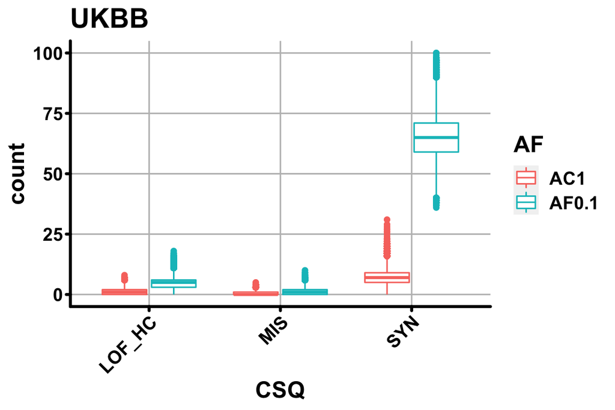

```r
count.variants <- function(variant.counts,samples,af.cutoff) {

  counts.AC1 <- variant.counts[UKBB.AC == 1,sum(gt),by=c("eid","CSQ")]
  counts.AC1[,AF:="AC1"]
  counts.AF0.1 <- variant.counts[UKBB.AF < af.cutoff,sum(gt),by=c("eid","CSQ")]
  counts.AF0.1[,AF:="AF0.1"]

  count.table <- bind_rows(counts.AC1,counts.AF0.1)

  samples.table <- data.table(crossing(samples=samples[,eid],CSQ=c("LOF_HC","MIS","SYN"),AF=c("AC1","AF0.1")))
  setnames(samples.table,"samples","eid")

  count.table <- merge(samples.table,count.table,by=c("eid","CSQ","AF"),all.x=T)
  count.table[,V1:=ifelse(is.na(V1),0,V1)]

  setnames(count.table,"V1","count")

  return(count.table)

}

UKBB.counts <- count.variants(variants.UKBB,samples.UKBB,0.001)
UKBB.plot <- ggplot(UKBB.counts,aes(CSQ,count,colour=AF)) + geom_boxplot() + ggtitle("UKBB") + ylim(0,100) + theme.legend
UKBB.genes <- variants.UKBB[CSQ == "SYN" & UKBB.AF<=1e-3,sum(gt),by=GENE]
setnames(UKBB.genes,"V1","UKBB")

UKBB.plot
```

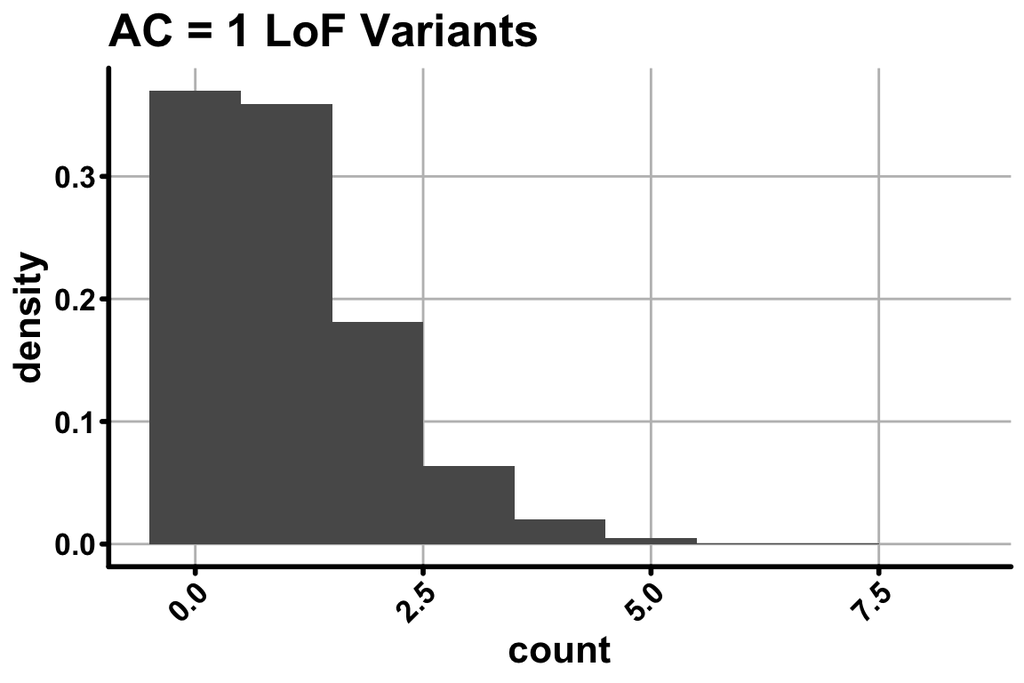

```r
ggplot(UKBB.counts[AF=="AC1" & CSQ=="LOF_HC"],aes(count,..density..)) + scale_alpha_discrete(range=c(1,0.5)) + geom_histogram(binwidth=1,position="identity") + ggtitle("AC = 1 LoF Variants") + theme.legend
```

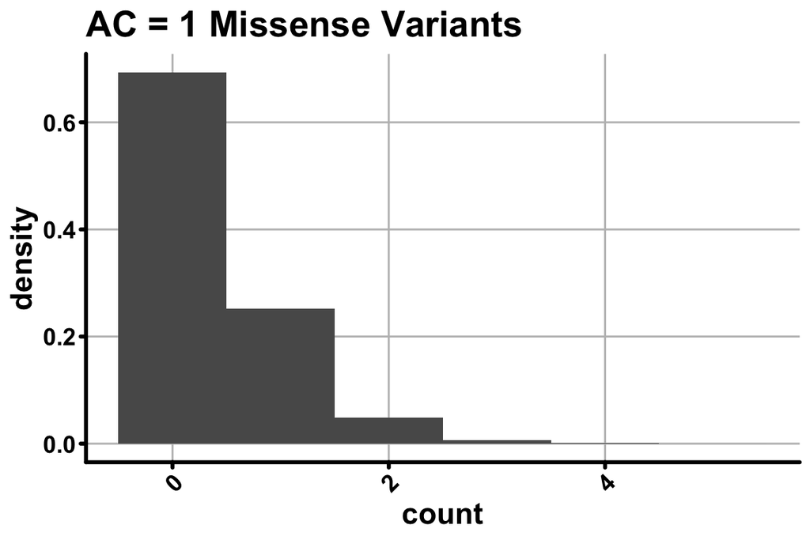

```r
ggplot(UKBB.counts[AF=="AC1" & CSQ=="MIS"],aes(count,..density..)) + scale_alpha_discrete(range=c(1,0.5)) + geom_histogram(binwidth=1,position="identity") + ggtitle("AC = 1 Missense Variants") + theme.legend
```

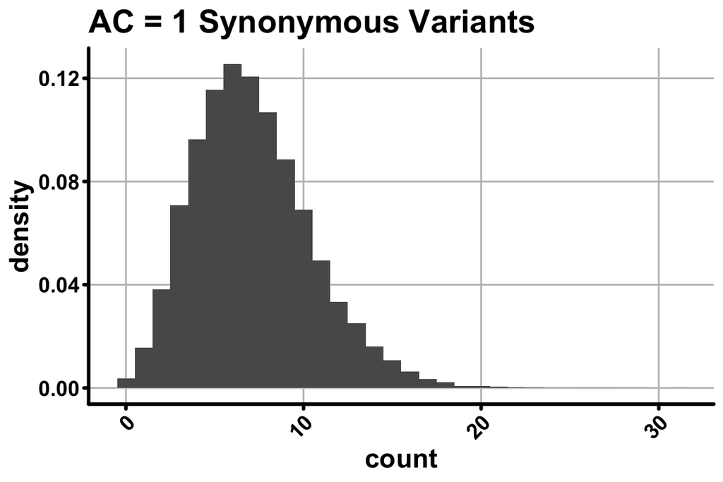

```r
ggplot(UKBB.counts[AF=="AC1" & CSQ=="SYN"],aes(count,..density..)) + scale_alpha_discrete(range=c(1,0.5)) + geom_histogram(binwidth=1,position="identity") + ggtitle("AC = 1 Synonymous Variants") + theme.legend
```

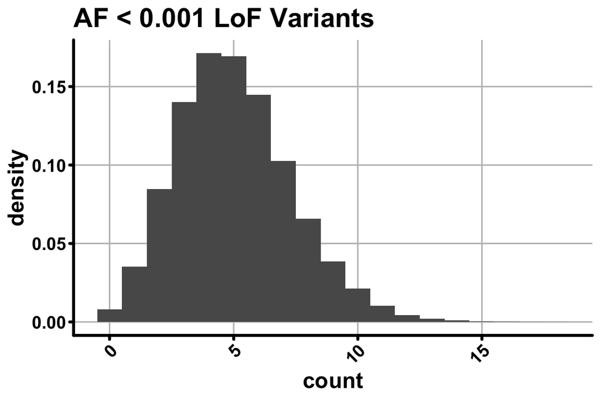

```r
ggplot(UKBB.counts[AF=="AF0.1" & CSQ=="LOF_HC"],aes(count,..density..)) + scale_alpha_discrete(range=c(1,0.5)) + geom_histogram(binwidth=1,position="identity") + ggtitle("AF < 0.001 LoF Variants") + theme.legend
```

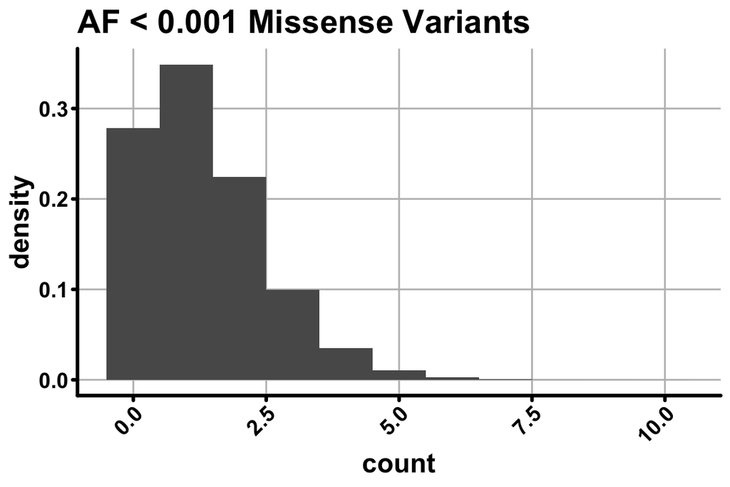

```r
ggplot(UKBB.counts[AF=="AF0.1" & CSQ=="MIS"],aes(count,..density..)) + scale_alpha_discrete(range=c(1,0.5)) + geom_histogram(binwidth=1,position="identity") + ggtitle("AF < 0.001 Missense Variants") + theme.legend
```

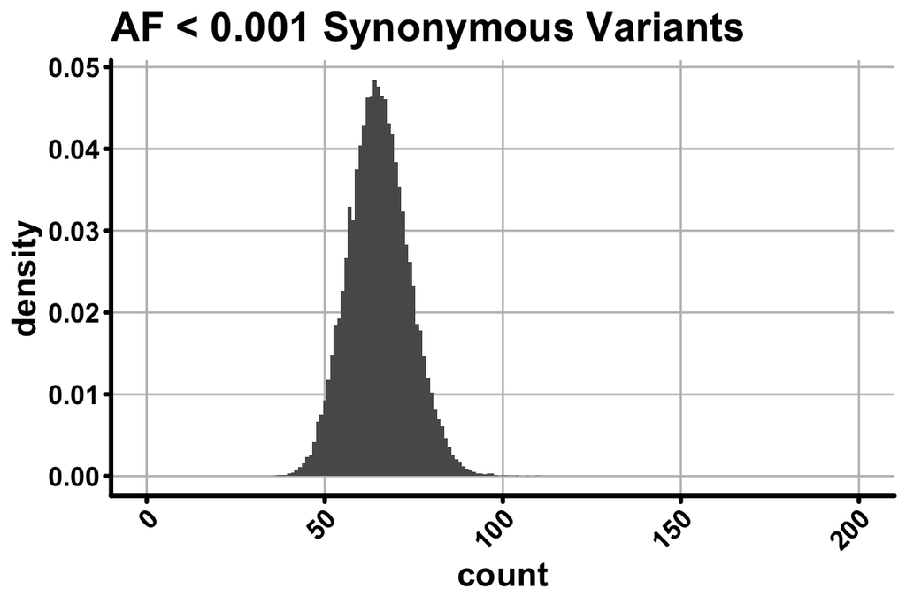

```r
ggplot(UKBB.counts[AF=="AF0.1" & CSQ=="SYN"],aes(count,..density..)) + scale_alpha_discrete(range=c(1,0.5)) + geom_histogram(binwidth=1,position="identity") + ggtitle("AF < 0.001 Synonymous Variants") + theme.legend + xlim(0,200)
```

```r
rm(UKBB.plot)
```

#### Variant Totals / Individual / Gene Group

This is where we make the variant count totals for each individual for the purposes of phenotype testing. We need to first remove LoF/Missense variants that are found in males as they are unlikely to be associated with phenotype. We then just count total number of variants in our gene lists from above.

```r
## We need to generate a list of common LoF/Missense variants found in males as they are unlikely to relate to phenotype of interest.
counts <- merge(variants.UKBB[CSQ == "MIS" | CSQ == "LOF_HC"],UKBB.phenotype.data[,c("eid","sexPulse")],by="eid")
sex.counts <- counts[,sum(gt),by=c("chr","pos","sexPulse","CSQ")]
sex.counts <- data.table(pivot_wider(sex.counts, names_from = "sexPulse", values_from="V1"))
sex.counts[is.na(sex.counts)] <- 0
setnames(sex.counts,c("2","1"),c("Female","Male"))
invalid.positions <- sex.counts[Female > 0 & Male > 0, c("chr","pos")]

## And count!
get.gene.counts.snvs <- function(data, samples, maf) {

    variants <- data.table(crossing(sample_id=samples[,eid],type=c("LOF_HC","SYN","MIS")))

    ## This handles the high pLI/sHET lists:
    for (gene.list in names(gene.lists)) {

      current.genes <- unlist(get(gene.list,gene.lists))

      ## Filter on frequency cutoff and gene list
      if (maf == 0) {
        counts <- data[UKBB.AC == 1 & GENE %in% current.genes & !pos %in% invalid.positions[,pos],sum(gt),by=c("eid","CSQ")]
      } else {
        counts <- data[UKBB.AF <= maf & GENE %in% current.genes & !pos %in% invalid.positions[,pos],sum(gt),by=c("eid","CSQ")]
      }

      variants <- merge(variants,counts,by.x=c("sample_id","type"),by.y=c("eid","CSQ"),all.x=T)
      variants[,V1:=if_else(is.na(V1),0L,V1)]
      setnames(variants,"V1",gene.list)

    }

    variants[,allele.freq:=maf]
    setcolorder(variants,c(names(variants)[-grep("type",names(variants))],c("type")))
    return(variants)
}

snv.counts <- bind_rows(get.gene.counts.snvs(variants.UKBB,samples.UKBB,0),
                        get.gene.counts.snvs(variants.UKBB,samples.UKBB,1e-3))
```

# 5. Variant Burden Impact on Traits

## 5A. Function for Linear Modeling

This code blob builds a function which does linear or logistic modeling for all my variant associations of the format:

$ phenotype n_{vars[i,v]} + age + age^2 + PC1..PC10 $

Where

```r
run.regression <- function(maf,
                           gene.list,
                           y.var,
                           variant.type) {

  cols.to.keep <- c("sample_id",gene.list)
  final.stats <- snv.counts[type == variant.type & allele.freq == maf,..cols.to.keep]

  if (variant.type == "LOF_HC") {
    final.stats <- final.stats[get(gene.list) <= 3]
  }

  final.stats <- merge(final.stats,UKBB.phenotype.data,by.x="sample_id",by.y="eid")

  ## Remove missing y.var data
  final.stats <- final.stats[!is.na(get(y.var))]

  ## Only females
  final.stats <- final.stats[sexPulse == 2]

  covariates <- c("PC1","PC2","PC3","PC4","PC5","PC6","PC7","PC8","PC9","PC10","agePulse.squared","agePulse")

  cov.string <- paste(covariates, collapse=" + ")
  formated.formula <- as.formula(paste(y.var, cov.string,sep=" ~ "))

  test.lm <- glm(formated.formula, data=final.stats, family="gaussian")
  resid.test <- augment(test.lm,data = final.stats) %>% data.table()

  formated.formula <- as.formula(paste(".resid", gene.list, sep = " ~ "))

  test.lm <- glm(formated.formula, data=resid.test, family="gaussian")
  coef.lm <- tidy(test.lm) %>% data.table()

  total.hits <- resid.test[,sum(get(gene.list))]

  return(list(coef.lm[term==eval(gene.list),estimate],
    coef.lm[term==eval(gene.list),std.error],
    coef.lm[term==eval(gene.list),p.value],
    total.hits,
    nrow(resid.test),
    list(resid.test)))

}
```

## 5B. Plotting Function

```r
plot.result <- function(data, ymin, ymax, y.lab) {

  plottable <- copy(data)
  ## This just makes it so the labels aren't 500 miles long:
  plottable[,gene.list.2:=factor(gene.list,
                                 levels=sort(unique(plottable[,gene.list])),
                                 labels=c(str_wrap(gsub("_"," ",gsub("\\."," ",sort(unique(plottable[,gene.list])))),width=20)))]

  ## Confidence Intervals and significance
  plottable[,var.ci.upper:=var.beta + (1.96*var.stderr)]
  plottable[,var.ci.lower:=var.beta - (1.96*var.stderr)]
  plottable[,sig.pos:=if_else(var.beta<0,var.ci.lower-0.05,var.ci.upper+0.05)]

  ylab <- "Effect Size"
  yline <- 0

  betas <- ggplot(plottable,aes(x=gene.list.2,y=var.beta,group=interaction(variant.type,maf),colour=variant.type,linetype=as.factor(maf))) +
    geom_hline(aes(yintercept=yline),linetype=2,colour="red") +
    geom_point(position=position_dodge(width=1),size=4) +
    scale_x_discrete(name="") +
    scale_y_continuous(name=ylab,limits = c(ymin,ymax)) +
    geom_errorbar(aes(ymin=var.ci.lower,ymax=var.ci.upper),position=position_dodge(width=1),width=0,size=2) +
    scale_fill_manual(values = alt.colours, labels = c("PTVs","Missense","Synonymous"), name = "Variant Type") +
    scale_color_manual(values = alt.colours, labels = c("PTVs","Missense","Synonymous"), name = "Variant Type") +
    scale_linetype_discrete(name = "MAF Threshold") +
    guides(fill="none") +
    theme.legend + theme(axis.text.x = element_blank(),  legend.key=element_rect(fill="white"))

  counts <- ggplot(plottable,aes(gene.list.2,n.var,group=interaction(variant.type,maf),fill=variant.type,linetype=as.factor(maf))) +
    geom_col(position=position_dodge(),colour="black") +
    scale_x_discrete(name="") +
    scale_y_log10(name=y.lab) +
    scale_fill_manual(values = alt.colours) +
    theme +
    theme(axis.text.x=element_blank(), legend.key=element_rect(fill="white"))

  plot <- (counts / betas) + plot_layout(heights=c(1,3),guides = "collect")

  return(plot)

}
```

## 5C. Female Carriers of Known Hemizygous DD Genes

### Fertility

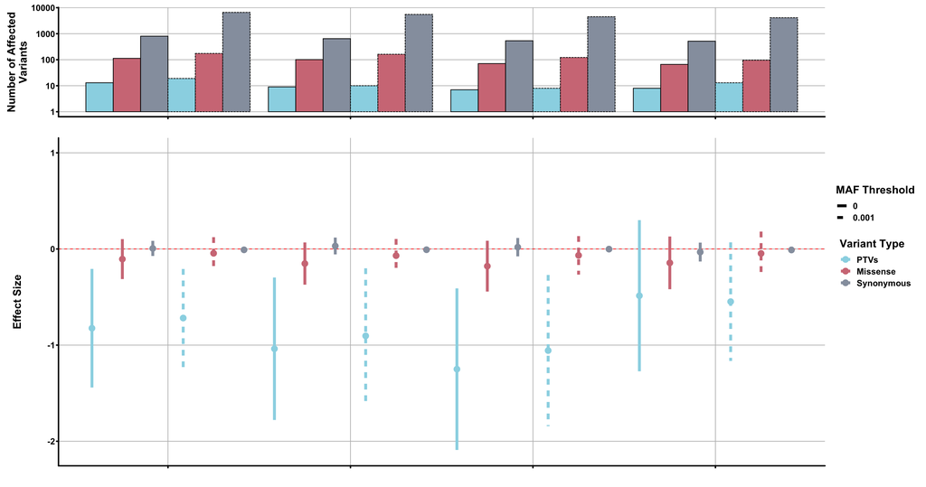

```r
results.hemi.fertility <- data.table(crossing(maf = c(0.001,0),
                                              gene.list = names(gene.lists)[grep("hemizygous",names(gene.lists))],
                                              y.var = c("live.births"),
                                              variant.type = c("LOF_HC","SYN","MIS")))

results.hemi.fertility[,c("var.beta","var.stderr","var.p","n.var","n.indvs","data"):=run.regression(maf,gene.list,y.var,variant.type),by=1:nrow(results.hemi.fertility)]

plot.result(results.hemi.fertility,-2.1,1,"Number of Affected\nVariants")
```

### Cognition

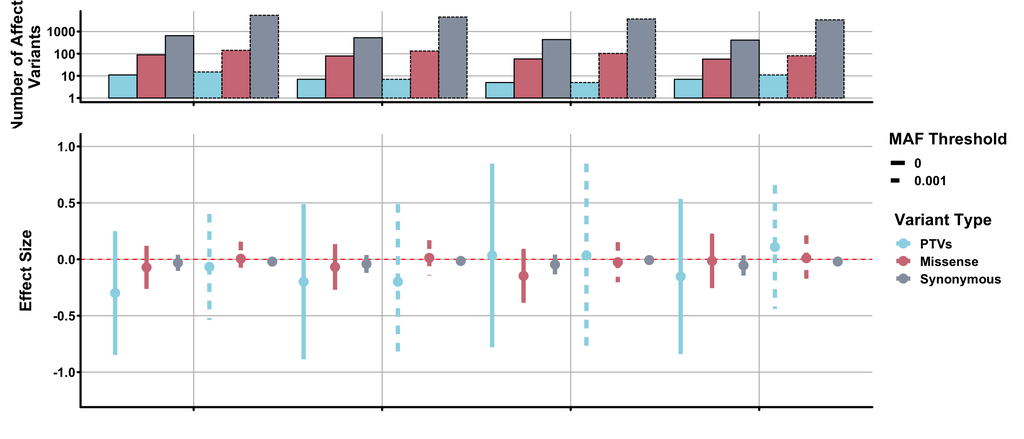

```r
results.hemi <- data.table(crossing(maf = c(0.001,0),
                                    gene.list = names(gene.lists)[grep("hemizygous",names(gene.lists))],
                                    y.var = c("fluid.intel"),
                                    variant.type = c("LOF_HC","SYN","MIS")))

results.hemi[,c("var.beta","var.stderr","var.p","n.var","n.indvs"):=run.regression(maf,gene.list,y.var,variant.type),by=1:nrow(results.hemi)]

plot.result(results.hemi,-1.2,1,"Number of Affected\nVariants")
```

# 6. Figures / Tables / Numbers

## 6A. Plotting Hemizygous Distributions and Figure

This (mostly) plots Supplementary Figure 4 – Still need to edit a bit in Illustrator to get it looking nice for publication.

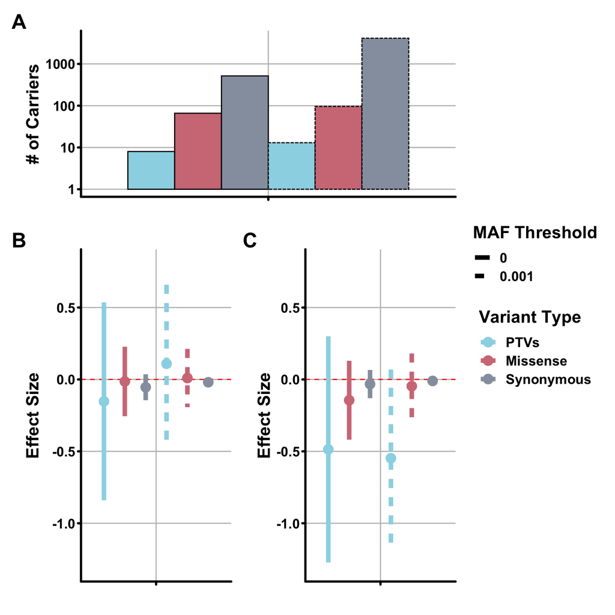

```r
plot.hemi.fertility <- plot.result(results.hemi.fertility[gene.list == "hemizygous_DD_genes_consensus"],-1.3,0.8,"# of Carriers")
plot.hemi.cognition <- plot.result(results.hemi[gene.list == "hemizygous_DD_genes_consensus"],-1.3,0.8,"# of Carriers")

plot <- plot.hemi.fertility[[1]] / (plot.hemi.cognition[[2]] + plot.hemi.fertility[[2]]) + plot_layout(nrow = 2, guides = "collect", heights = c(1,2)) + plot_annotation(tag_levels = 'A')

plot
```

```r
ggsave("figures/UKBB_fertility.SuppFig4.svg",plot,units=c("in"),width=10,height=10)
```

## 6B. Fertility Ratio

This calculates the fertility ratio as presented in the main text.

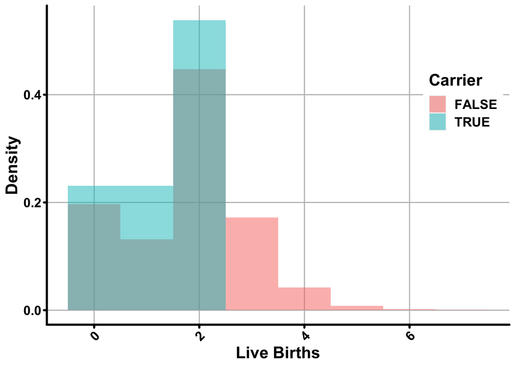

```r
## Actual density plot
plot.hemi <- snv.counts[allele.freq == 1e-3 & type == "LOF_HC",c("sample_id","hemizygous_DD_genes_consensus")]
plot.hemi <- merge(plot.hemi, UKBB.phenotype.data, by.x = "sample_id", by.y = "eid")
plot.hemi <- plot.hemi[sexPulse==2 & !is.na(live.births)]

density.plot <- ggplot(plot.hemi,aes(live.births,..density..,group=as.factor(hemizygous_DD_genes_consensus),fill=as.factor(hemizygous_DD_genes_consensus))) +
  scale_fill_discrete(guide=guide_legend(title = "Carrier"),labels=c("FALSE","TRUE")) +
  geom_histogram(alpha=0.5,position="identity",bins=8) +
  ylab("Density") +
  xlab("Live Births") +
  theme.legend +
  theme(legend.position=c(0.9,0.7))

density.plot
```

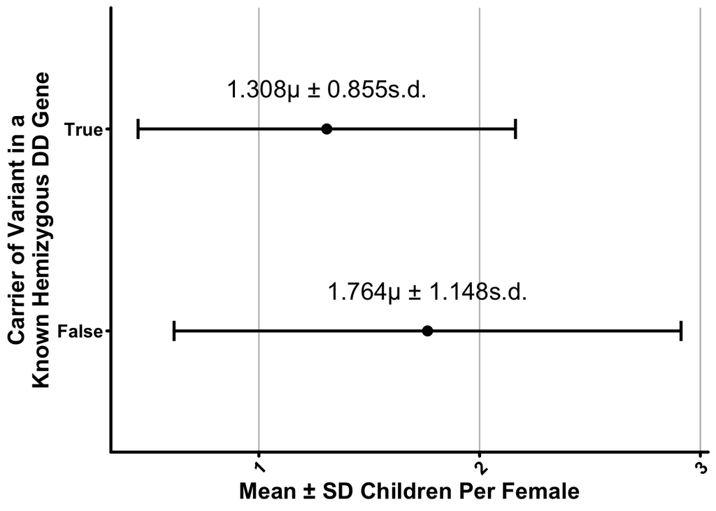

```r
## Plot Mean Fertility for carrier vs. non carriers
means <- plot.hemi[,list(mean(live.births),sd(`live.births`),median(`live.births`)),by="hemizygous_DD_genes_consensus"]
setnames(means,c("V1","V2","V3"),c("mean","sd","median"))

means.plot <- ggplot(means,aes(as.factor(hemizygous_DD_genes_consensus),mean)) +
  geom_point(size=3) +
  geom_errorbar(aes(ymin=mean-sd,ymax=mean+sd),width=0.1,size=1) +
  geom_text(aes(y=mean,label=paste0(sprintf("%0.3f",mean),"μ ± ",sprintf("%0.3f",sd), "s.d.")),size=6,position=position_nudge(.2,0)) +
  coord_flip() +
  scale_x_discrete(name="Carrier of Variant in a\nKnown Hemizygous DD Gene",labels=c("False","True")) +
  scale_y_continuous("Mean ± SD Children Per Female") +
  theme +
  theme(panel.grid.major.y=element_blank())

means.plot
```

```r
## Now calculate a fertility ratio corrected for age/PCs
result.residuals <- results.hemi.fertility[maf == 1e-3 & gene.list == "hemizygous_DD_genes_consensus" & variant.type == "LOF_HC",data][[1]]
result.residuals[,corrected:=`.resid` - min(result.residuals[,`.resid`])]
mean.resids <- result.residuals[,list(mean(corrected),sd(corrected),median(corrected)),by="hemizygous_DD_genes_consensus"]
setnames(mean.resids,c("V1","V2","V3"),c("mean","sd","median"))

formated.formula <- as.formula(paste("corrected",paste0("as.factor(hemizygous_DD_genes_consensus)"),sep=" ~ "))
ratio.test <- ttestratio(formated.formula,data=result.residuals,base=1)

paste0("Fertility Ratio ", sprintf("%0.3f",ratio.test$estimate[[3]])," [", sprintf("%0.3f",ratio.test$conf.int[1]),"-", sprintf("%0.3f",ratio.test$conf.int[2]), "]", " (p = ",sprintf("%0.3f",ratio.test$p.value),")")
```

```
## [1] "Fertility Ratio 0.742 [0.503-0.981] (p = 0.037)"
```

```r
paste0("Number of Carriers : ", nrow(plot.hemi[hemizygous_DD_genes_consensus > 0]))
```

```
## [1] "Number of Carriers : 13"
```

```r
paste0("Fertility of Carriers : ", sprintf("%0.2f",plot.hemi[hemizygous_DD_genes_consensus > 0, mean(live.births)]))
```

```
## [1] "Fertility of Carriers : 1.31"
```

```r
paste0("Fertility of Non-Carriers : ", sprintf("%0.2f",plot.hemi[hemizygous_DD_genes_consensus == 0, mean(live.births)]))
```

```
## [1] "Fertility of Non-Carriers : 1.76"
```

## 6C. Supplemental Table of Variants

This generates an unformated version of Supplementary Table 4. We added in the name of the gene manually after printing this table based on ENSG ID.

```r
supp.table.xx <- variants.UKBB[eid %in% plot.hemi[hemizygous_DD_genes_consensus > 0, sample_id] & CSQ == "LOF_HC" & GENE %in% unlist(gene.lists["hemizygous_DD_genes_consensus"])]

supp.table.xx <- supp.table.xx[,c("pos","ref","alt","GENE","CADD","UKBB.AC")]
setnames(supp.table.xx, names(supp.table.xx), c("position","ref. allele","alt. allele","ENSEMBL Gene ID", "CADDv1.5", "Allele Count"))

write.table(supp.table.xx,"Figures/UKBB_fertility.SuppTable4.txt",row.names = F, col.names = T, sep = "\t", quote = F)
```